# 实测 GPT Image 2.5：5分钱生成高写实效果

# 实测GPT Image 2.5：5分钱生成高写实效果，极速出图。言出法随的时代到了。

[figure not shown]

做电商物料或者产品海报，最耗时间的往往不是画画，而是后期：抠图、去背景、修白边，再把一堆零散素材拼到同一个画布里。

如果生图模型一开始就能吐出“免抠透明底”，后期的排版效率能直接翻倍。

OpenAI 刚推出的 **GPT Image 2.5**（包含 Flare 和 Sunburst 两个版本）正式支持了原生透明背景输出。我们通过 NoneLinear API 跑了一轮深度实测：从单品透明图、局部细节修改、双图融合排版，一路测到了最高画质档位。

**整整 20 次实调，总共花了 6.08 元。**

其中最实用的，就是下面这张直接带 Alpha 透明通道的精华液瓶身——**单张只要 0.046 元，还不到 5 分钱。**

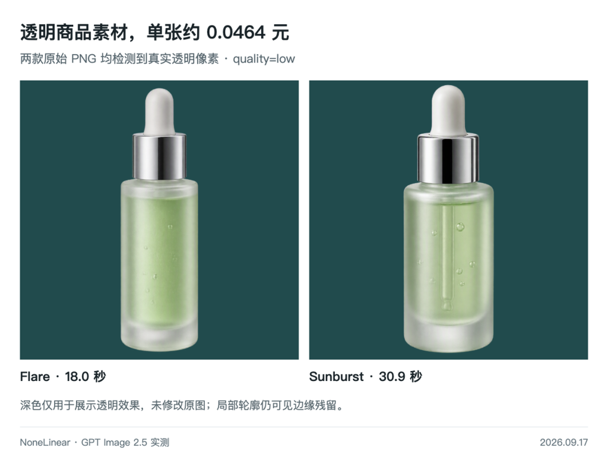

*注：深色背景仅用于衬托瓶身；下载得到的原图为真正带透明通道的 PNG，未经过任何 PS 去底或修边。*

## 01. 找灵感打样，4分钱一张完全够用

平时做新品提案或设计脑暴，第一张图通常是用来定大方向的：瓶身质感、液体反光、瓶盖搭配，先出几张具象图，大家的沟通成本立马就降下来了。

我们先用最基础的提示词（磨砂玻璃、浅绿液体、银色滴管盖），把两款模型都调到 low 低画质档位试水。

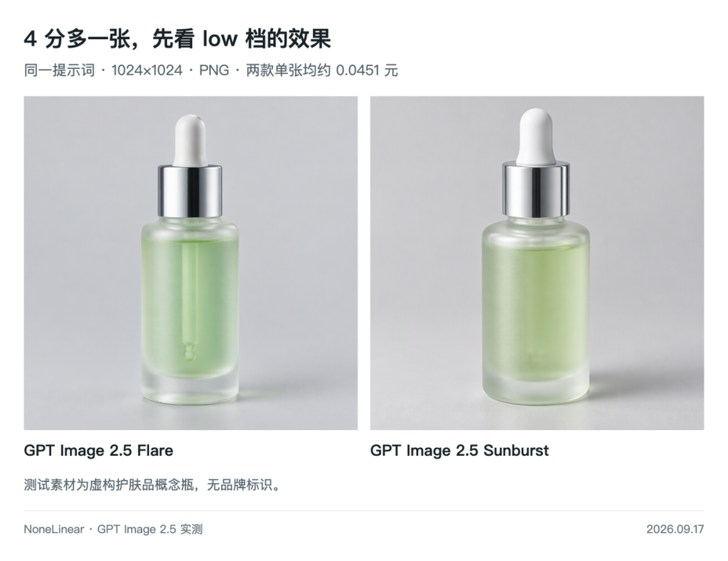

单张费用都是 **0.045 元**，耗时在 27~28 秒左右。

两款模型的出图风格差异很直观：

- **Flare**：整体画面更干净通透，高光反射比较锐利，出图有典型商业广告图的清爽感；
- **Sunburst**：对玻璃漫反射、液体折射细节的处理更丰富一些，层次偏写实。

就拿来当方案参考或草图来说，这个画质表现对得起 4 分钱的成本。

## 02. 原生透明底到底干不干净？实测边缘有讲究

生成完瓶子，通常要放进白底详情页、品牌色海报或者 PPT 里，免不了要换背景。

这次两个模型确实都吐出了**原生的透明 PNG**。大面积的背景被干净彻底地扣掉了，直接省去了魔棒工具选区的繁琐步骤。

**但能不能直接拿来做商业成品？得看细节。**

把原图放大后拖进深色和高对比度背景里，能观察到几个细节：

1. **边缘过渡**：瓶身边缘基本没有生硬的白边，但瓶口滴管和玻璃边缘略带一点微弱的半透明噪点；
2. **材质穿透**：由于玻璃本身具有半透明属性，底层透过来的暗部处理得比较自然；
3. **实操建议**：如果放在浅色、微灰或者普通电商白底上，完全看不出破绽，可以直接用；但如果要贴在大面积纯黑背景或精细印刷物料上，建议顺手用蒙版微调一下边缘。

另外，调用和保存有两个特别容易踩的坑：

第一，调 API 时除了提示词注明透明背景，**这两个参数必须带上**：

```json
{ "background": "transparent", "output_format": "png" }
```

第二，**千万不要直接在网页聊天窗口或预览窗口里右键另存图片！** 很多浏览器展示预览时会将其转码为无透明通道的 WebP 或 JPG，导致白忙一场。一定要从 API 返回的 url 地址下载原版 PNG。

## 03. 局部修改与双图拼版：听话程度超出预期

局部重绘一直是很多设计师的噩梦——很多 AI 工具你让它修个纽扣，它顺便把整张脸和背景都给重画了。

我们找了一张纯白背景的红色马克杯，提了一个极其克制的要求：**只在杯口沿加一圈描金，杯身形状、光影反光、白色背景一概保留。**

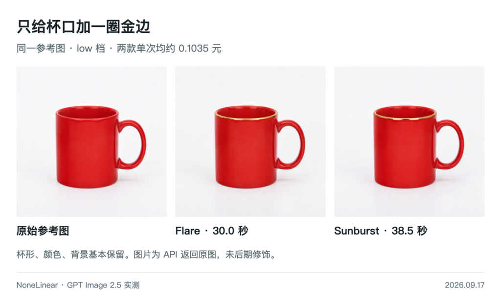

结果令人惊喜：两款模型都没有“自作聪明”去动杯子主体，金边很老实地贴在了杯口轮廓上，陶瓷反光几乎原样保留。

单次修改耗费 **0.103 元**，Flare 耗时约 30 秒，Sunburst 约 39 秒。用这个功能来做快速的包装改色、加装饰条、改配件材质，实用性非常强。

更进了一步，我们做了多图融合测试：**把刚刚的红杯与精华液瓶作为两张参考图，要求左杯右瓶，合成在一张浅灰背景的产品摄影棚台面上。**

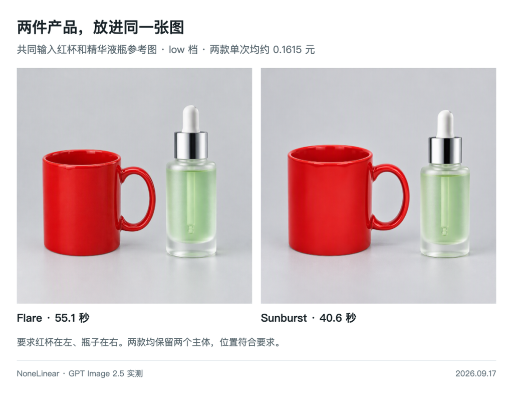

很多拼贴工具做出来的图，两个物体往往各晒各的太阳，透视完全对不上。但这组结果里，杯子和瓶子的主光源被统一梳理过了，台面阴影的走向一致，并没有明显的悬浮违和感。

单次合成费用是 **0.161 元**。这次更注重细节的 Sunburst 速度更快，41 秒出图（Flare 跑了 55 秒）。做组合装提案、礼盒搭配预览，这种拼版能力已经完全能派上用场。

## 04. 画质档位与踩坑提醒：最高画质跑了4分多钟

GPT Image 2.5 新增了 xhigh 和 max 档位。我们用同一套提示词把各个画质跑了一圈，价格和耗时的数据对比非常惊人：

| 画质档位 | 单张实测费用（元） | Flare 耗时（秒） | Sunburst 耗时（秒） |
| --- | --- | --- | --- |
| low | 0.045 | 27.5 | 28.2 |
| medium | 0.096 | 22.1 | 40.8 |
| high | 0.373 | 40.4 | 79.1 |
| xhigh | 0.660 | 42.2 | 124.3 |
| max | 1.479 | 85.4 | 257.4 |
| auto | 0.045 | 24.9 | 39.1 |

*注：基于同一组提示词与 1024×1024 尺寸实测，耗时不含图片下载。*

从 low 档的 **0.045 元**，一路跳到了 max 档的 **1.48 元**，价格翻了 30 多倍。

比价格更需要提防的是**耗时**：

- 测到 Sunburst 的 max 档时，足足等了 **257 秒（4 分 17 秒）** 才出图！
- **踩坑预警**：如果你用自己的后端代码或开源 WebUI 接入，很多网络库默认的超时时间（timeout）只有 60 秒。跑 max 档极容易被客户端主动掐断报错，超时阈值一定要拉长。

另外，官方提供的 auto 档位在本次实测中自动选了 low，并没有智能拉满，别把它误当成“自动最高画质”。

**日常使用建议**：找方案、试构图、出初稿，无脑锁死 low 档，4 分钱一张又快又便宜；只有定稿准备做大图时，再单独用高画质重跑一遍。

## 05. 怎么在本地跑起来？（附可直接跑的 curl）

上面所有的测试，都基于 **NoneLinear API** 完成。

两款模型（Flare 与 Sunburst）接入的是同一套标准端点，切换测试只要改一下 model 参数，不需要写两套适配逻辑。

新用户注册 NoneLinear 目前会赠送 **5 元免费体验额度**。按低档透明图一张 0.046 元来算，这 5 块钱够你完整测上 100 来张图，足够体验核心功能。

想要自己跑跑看，按下面三步走：

1. 到 NoneLinear 官网 登录，在 API Key 页面 拿到自己的密钥；
2. 复制下面的命令行脚本，把 YOUR_API_KEY 替换成你的密钥；
3. 直接在终端运行：

```bash
curl -sS --max-time 600 \
  https://api.nonelinear.com/v1/images/generations \
  -H "Authorization: Bearer YOUR_API_KEY" \
  -H "Content-Type: application/json" \
  -d '{
    "model": "gpt-image-2.5-flare",
    "prompt": "一瓶护肤品概念精华液，磨砂玻璃瓶身，浅绿色液体，银色滴管盖，无文字和品牌标识，完整瓶身居中，正面略微侧转，专业产品摄影，材质细节清晰。透明背景，不要白色或纯色背景，不要场景、地面、底座、投影和额外物体。",
    "response_format": "url",
    "output_format": "png",
    "background": "transparent",
    "size": "1024x1024",
    "quality": "low",
    "n": 1
}'
```

**快来试试吧！**

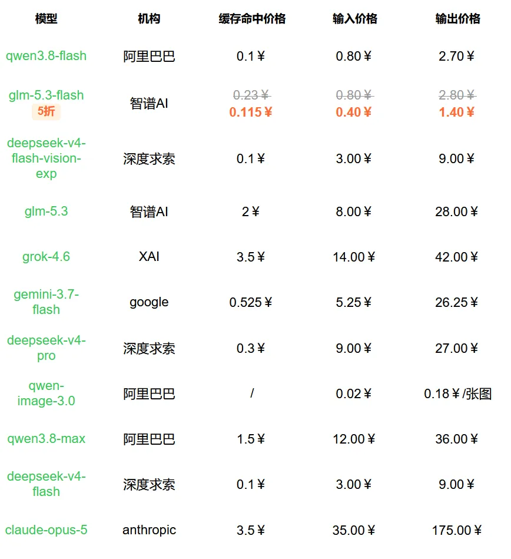

**非线智能 NoneLinear**

- 新用户福利：9 月 20 日前注册，免费送 50–100 张图
- 充值优惠：充 5000 送 500，全部模型折扣共享

[figure not shown]

📎 **原始 Word 文件**：05-GPT-Image-2.5实测.docx